# exploring business establishments in the city of melbourne by Anzsic4 classification and CLUE small area

An Interactive Geospatial and Economic Analysis for City of Melbourne for Business Insights

**Authored by:** Naga Nikhil Woopalanchi

**Duration:** 120 mins

**Level:** Advanced

**Pre-requisite Skills:** Python, Machine Learning, Deep Learning (Tensorflow), Predictive Analysis

**Scenario**

The City of Melbourne is seeking to develop a comprehensive tool that can aid urban planners, policymakers, and business owners in fostering economic growth and supporting local businesses. To acheive this, they require a deep understanding of the city's business landscape, including the location, industry classification, and job creation of businesses within the city.

This use case focuses on creating an interactive platform that integrates multiple datasets to provide a holistic view of the business environment in the City of Melbourne. The core component of this projects included street data providing geographic coordinates of property addresses, business establishment data covering from period 2002 to 2022 with information on business address, industry classification (ANZSIC4), location, CLUE small area and CLUE industry classification, as well as business establishments and job data offering insights into the number of jobs and business establishments.

At the end of this use case you will:

- **Data Integration:** Merging and integrating diverse datasets using common identifiers.
- **Data Cleaning:** Handling missing values,correcting inconsistencies, and preparing data for analysis.
- **Exploratory Data Analysis:** Uncovering patterns, trends, and relationship through visulizations.
- **Geospatial Analysis:** Mapping business locations and analysing spatial distributions using GIS.
- **Data Modeling:** Building predictive models for economic and urban analysis.
- **Industry Insights:** Understanding the economic structure of the City of Melbourne by industry and size.
- **Urban Planning & Economic Development:** Analyzing the link between activity, urban planning, and growth.
- **Project Management:** Managing a data science project from data acquisition to presenting result.

**Description of the problem**

To aid urban planner/policymaker/business owner in the City of Melbourne, I want to have a comprehension understanding of the city's business landscape, so that I can make informed decisions, support existing business, and foster economic growth in region.

Specifically, I need to be able to:

1. Understanding geographical distribution of different businessess in the City of Melbourne, including location and clustering of different industries.
2. Analyze the industry composition of the business community, including the number and size of establishments, as well as the number of jobs provided by each industry.
3. Identifying potential area for business development and growth, based on factors such as industry concentration, job creation, and emerging trends.
4. Support local businesses by providing insights into the competitive landscape, market opportunities, and potential areas for collaboration or resource sharing.
5. Inform policymaking and urban planning decisions, such as infrastructure investments, zoning regulations, and economic development stratergies, to create a more conductive environment for businesses to thrive.

By having access to a comprehensive and integrated platform that combines various datasets on the city's businessess, I will be able to make data-driven decisions, identify areas of oppurtunity, and implement policies and initiatives that foster a vibrant and prosperious business community in the City of Melbourne.

**Introduction**

The City of Melbourne is seeking to develop a comprehensive tool that can aid urban planners, policymakers, and business owners in fostering economic growth and supporting local businessess. To acheive this, they require a deep understanding of the city's business landscape, including the location, industry classification, and job creation of businesses within the city.

This project aims to create a robust and interactive platform that integrates multiple datasets to provide a holistic view of the business environment in the City of Melbourne. The key componenets of the project include street data, business establishment data from 2002 to 2022 and job creation data. By combining these datasets owners with a powerful tool that can support informed decision-making,foster economic growth, and enhance the overall business environment within the City of Melbourne.

The dataset required for this project include:

1. Street data providing the geographic coordinates of property address.
2. Business establishment data covering the period from 2002 to 2022 with information on business address, industry classification (ANZSIC4), and CLUE small area location classification.
3. Business establishments and jobs data offering insights into the number of jobs and business establishments categorised by business size, CLUE industry, ANZSIC1 and CLUE small area allocation.

This project involves a series of steps, including data cleaning, data exploration, data preprocessing, exploratory data analysis, and predictive modeling. By leveraging these techniques, the project ai,s to uncover patterns, trends, and relationships within the City of Melbourne's business landscape, ultimately aid informed decision-making, fostering economic growth, and enhancing the overall business environment.

# Importing Libraries

Importing the required python modules

```python
import warnings
warnings.filterwarnings("ignore")

import requests
import numpy as np
import pandas as pd
import seaborn as sns
from io import StringIO
import matplotlib.pyplot as plt
import geopandas as gpd
from shapely.geometry import Point
import holoviews as hv
import folium
from folium.plugins import MarkerCluster, HeatMap
from wordcloud import WordCloud
from sklearn.model_selection import train_test_split
from sklearn.preprocessing import StandardScaler, OneHotEncoder
from sklearn.compose import ColumnTransformer
from sklearn.pipeline import Pipeline
from sklearn.ensemble import RandomForestClassifier, RandomForestRegressor
from sklearn.metrics import classification_report, confusion_matrix, mean_squared_error, mean_absolute_error, r2_score
import plotly.express as px
from sklearn.linear_model import LogisticRegression, LinearRegression
from shapely import wkt
from IPython.display import display, HTML
from scipy.spatial import distance
from scipy.stats import gaussian_kde
import contextily as ctx
from statsmodels.tsa.stattools import acf, pacf
from statsmodels.tsa.arima.model import ARIMA
from statsmodels.tsa.holtwinters import ExponentialSmoothing
from statsmodels.tsa.api import VAR
from math import sqrt
from pmdarima import auto_arima
from statsmodels.tsa.stattools import adfuller
import tensorflow as tf
from tensorflow.keras.models import Sequential
from tensorflow.keras.layers import Dense
```

```python
# Street address

base_url='https://data.melbourne.vic.gov.au/api/explore/v2.1/catalog/datasets/'
dataset_id='street-addresses'


url=f'{base_url}{dataset_id}/exports/csv'
params={'select':'*','limit':-1,'lang':'en','timezone':'UTC'}

response=requests.get(url,params=params)

if response.status_code==200:
    url_content=response.content.decode('utf-8')
    street_add=pd.read_csv(StringIO(url_content),delimiter=';')  #renaming dataset
    print(street_add.head(10))
else:
    print(f'Request failed with status code {response.status_code}')
```

```
                         geo_point_2d  \
0  -37.802381557572, 144.941473440919
1  -37.816860132435, 144.969991449806
2  -37.798830275265, 144.942872100233
3  -37.810546771396, 144.970906397029
4  -37.789293657657, 144.939794028368
5  -37.800782747366, 144.951363910142
6  -37.826775193662, 144.959358160779
7  -37.810925617843, 144.965443591832
8   -37.81275302482, 144.964263891172
9   -37.821209833971, 144.95403377339

                                           geo_shape  suburb_id   latitude  \
0  {"coordinates": [144.941473440919, -37.8023815...      592.0 -37.802382
1  {"coordinates": [144.969991449806, -37.8168601...      591.0 -37.816860
```

[output cut: 44 more lines]

```python
# Business establishments and jobs data by business size and industry

base_url='https://data.melbourne.vic.gov.au/api/explore/v2.1/catalog/datasets/'
dataset_id='business-establishments-and-jobs-data-by-business-size-and-industry'


url=f'{base_url}{dataset_id}/exports/csv'
params={'select':'*','limit':-1,'lang':'en','timezone':'UTC' }

response=requests.get(url,params=params)

if response.status_code==200:
    url_content=response.content.decode('utf-8')
    # Renaming the dataset as bizsize_industry jobs
    industrysize_jobs =pd.read_csv(StringIO(url_content),delimiter=';')
    print(industrysize_jobs.head(10))
else:
    print(f'Request failed with status code {response.status_code}')
```

```
   census_year               clue_small_area  \
0         2015  West Melbourne (Residential)
1         2015  West Melbourne (Residential)
2         2015  West Melbourne (Residential)
3         2015  West Melbourne (Residential)
4         2015  West Melbourne (Residential)
5         2015  West Melbourne (Residential)
6         2014                       Carlton
7         2014                       Carlton
8         2014                       Carlton
9         2014                       Carlton

                                   anzsic_indusrty  \
0                Health Care and Social Assistance
1                                    Manufacturing
```

[output cut: 32 more lines]

```python
# Business establishments with address and industry classification

base_url='https://data.melbourne.vic.gov.au/api/explore/v2.1/catalog/datasets/'
dataset_id='business-establishments-with-address-and-industry-classification'


url=f'{base_url}{dataset_id}/exports/csv'
params={'select':'*','limit':-1,'lang':'en','timezone':'UTC'}

response=requests.get(url,params=params)

if response.status_code==200:
    url_content=response.content.decode('utf-8')
    # Renaming the dataset as bizaddressindustry
    industryinfo_classification=pd.read_csv(StringIO(url_content),delimiter=';')
    print(industryinfo_classification.head(10))
else:
    print(f'Request failed with status code {response.status_code}')
```

```
   census_year  block_id  property_id  base_property_id clue_small_area  \
0         2017       266       109851            109851         Carlton
1         2017       266       109851            109851         Carlton
2         2017       266       534003            534003         Carlton
3         2017       266       664003            664003         Carlton
4         2017       266       664005            664005         Carlton
5         2017       266       664009            664009         Carlton
6         2017       267       102614            102614         Carlton
7         2017       267       102614            102614         Carlton
8         2017       267       106251            106251         Carlton
9         2017       267       106251            106251         Carlton

                   trading_name  \
0  Metropoli's Research Pty Ltd
1             J Hong Restaurant
```

[output cut: 32 more lines]

# Data Snippets

To understand and gain familirity with our dataset, we first examine its structure by checking the number of rows and columns of different dataset. This will help us understanding the datasize and complexity, revealing how different variables and stored and their formats. It would help us understand which columns might futher require further cleaning or transformation and gives us insights into the nature of data we'll be working.

```python
#Street address data set

street_add.head()
```

|  | geo_point_2d | geo_shape | suburb_id | latitude | street_no | str_name | address_pnt | easting | northing | gisid | longitude | suburb | street_id | add_comp |
| --- | --- | --- | --- | --- | --- | --- | --- | --- | --- | --- | --- | --- | --- | --- |
| 0 | -37.802381557572, 144.941473440919 | {"coordinates": [144.941473440919, -37.8023815... | 592.0 | -37.802382 | 133 | Laurens Street | 133 Laurens Street North Melbourne | 318773.161972 | 5.814115e+06 | 48531 | 144.941473 | North Melbourne | 781 | NaN |
| 1 | -37.816860132435, 144.969991449806 | {"coordinates": [144.969991449806, -37.8168601... | 591.0 | -37.816860 | 129 | Flinders Street | 129 Flinders Street Melbourne | 321318.983104 | 5.812563e+06 | 37711 | 144.969991 | Melbourne | 636 | NaN |
| 2 | -37.798830275265, 144.942872100233 | {"coordinates": [144.942872100233, -37.7988302... | 592.0 | -37.798830 | 44 | Macaulay Road | 44 Macaulay Road North Melbourne | 318887.633593 | 5.814512e+06 | 30476 | 144.942872 | North Melbourne | 847 | NaN |
| 3 | -37.810546771396, 144.970906397029 | {"coordinates": [144.970906397029, -37.8105467... | 591.0 | -37.810547 | 13 | Punch Lane | 13 Punch Lane Melbourne | 321384.307636 | 5.813265e+06 | 35165 | 144.970906 | Melbourne | 1003 | NaN |
| 4 | -37.789293657657, 144.939794028368 | {"coordinates": [144.939794028368, -37.7892936... | 592.0 | -37.789294 | 61 | Racecourse Road | 61 Racecourse Road North Melbourne | 318593.277492 | 5.815564e+06 | 22247 | 144.939794 | North Melbourne | 119624 | NaN |

```python
# Street addressess dataset datatype information

street_add.info()
```

```
<class 'pandas.core.frame.DataFrame'>
RangeIndex: 63721 entries, 0 to 63720
Data columns (total 14 columns):
 #   Column        Non-Null Count  Dtype
---  ------        --------------  -----
 0   geo_point_2d  63721 non-null  object
 1   geo_shape     63721 non-null  object
 2   suburb_id     63715 non-null  float64
 3   latitude      63721 non-null  float64
 4   street_no     63069 non-null  object
 5   str_name      63720 non-null  object
 6   address_pnt   63721 non-null  object
 7   easting       63721 non-null  float64
 8   northing      63721 non-null  float64
 9   gisid         63721 non-null  int64
 10  longitude     63721 non-null  float64
 11  suburb        62991 non-null  object
 12  street_id     63721 non-null  int64
 13  add_comp      1352 non-null   object
dtypes: float64(5), int64(2), object(7)
memory usage: 6.8+ MB
```

The street address dataset consists of 14 columns with a total of 63721 rows. The street address dataset contains the location information including latitude, longitute, Northing and Easting of every property address within the City of Melbourne.

```python
# Business establishments and jobs data by business size and industry
industrysize_jobs.head()
```

|  | census_year | clue_small_area | anzsic_indusrty | clue_industry | business_size | total_establishments | total_jobs |
| --- | --- | --- | --- | --- | --- | --- | --- |
| 0 | 2015 | West Melbourne (Residential) | Health Care and Social Assistance | Health Care and Social Assistance | Large business | 1 | NaN |
| 1 | 2015 | West Melbourne (Residential) | Manufacturing | Manufacturing | Medium business | 5 | 171.0 |
| 2 | 2015 | West Melbourne (Residential) | Manufacturing | Manufacturing | Non employing | 1 | NaN |
| 3 | 2015 | West Melbourne (Residential) | Professional, Scientific and Technical Services | Business Services | Non employing | 3 | 0.0 |
| 4 | 2015 | West Melbourne (Residential) | Rental, Hiring and Real Estate Services | Real Estate Services | Small business | 5 | 42.0 |

```python
# Business establishments and jobs data by business size and industry
#datatype information

industrysize_jobs.info()
```

```
<class 'pandas.core.frame.DataFrame'>
RangeIndex: 14692 entries, 0 to 14691
Data columns (total 7 columns):
 #   Column                Non-Null Count  Dtype
---  ------                --------------  -----
 0   census_year           14692 non-null  int64
 1   clue_small_area       14692 non-null  object
 2   anzsic_indusrty       14692 non-null  object
 3   clue_industry         14692 non-null  object
 4   business_size         14692 non-null  object
 5   total_establishments  14692 non-null  int64
 6   total_jobs            10365 non-null  float64
dtypes: float64(1), int64(2), object(4)
memory usage: 803.6+ KB
```

```python
# Business establishments location and industry classification
industryinfo_classification.head()
```

|  | census_year | block_id | property_id | base_property_id | clue_small_area | trading_name | business_address | industry_anzsic4_code | industry_anzsic4_description | longitude | latitude |
| --- | --- | --- | --- | --- | --- | --- | --- | --- | --- | --- | --- |
| 0 | 2017 | 266 | 109851 | 109851 | Carlton | Metropoli's Research Pty Ltd | Level 1, 74 Victoria Street CARLTON 3053 | 6950 | Market Research and Statistical Services | 144.965352 | -37.806701 |
| 1 | 2017 | 266 | 109851 | 109851 | Carlton | J Hong Restaurant | Ground , 74 Victoria Street CARLTON 3053 | 4511 | Cafes and Restaurants | 144.965352 | -37.806701 |
| 2 | 2017 | 266 | 534003 | 534003 | Carlton | St2 Expresso | 70 Victoria Street CARLTON 3053 | 4512 | Takeaway Food Services | 144.965473 | -37.806714 |
| 3 | 2017 | 266 | 664003 | 664003 | Carlton | RMIT Resources Ltd | 20 Cardigan Street CARLTON 3053 | 8102 | Higher Education | 144.964753 | -37.806312 |
| 4 | 2017 | 266 | 664005 | 664005 | Carlton | vacant | 24 Cardigan Street CARLTON 3053 | 0 | Vacant Space | 144.964772 | -37.806203 |

```python
# Business establishments location and industry classification datatype information
industryinfo_classification.info()
```

```
<class 'pandas.core.frame.DataFrame'>
RangeIndex: 374210 entries, 0 to 374209
Data columns (total 11 columns):
 #   Column                        Non-Null Count   Dtype
---  ------                        --------------   -----
 0   census_year                   374210 non-null  int64
 1   block_id                      374210 non-null  int64
 2   property_id                   374210 non-null  int64
 3   base_property_id              374210 non-null  int64
 4   clue_small_area               374210 non-null  object
 5   trading_name                  374083 non-null  object
 6   business_address              374209 non-null  object
 7   industry_anzsic4_code         374210 non-null  int64
 8   industry_anzsic4_description  374210 non-null  object
 9   longitude                     369425 non-null  float64
 10  latitude                      369425 non-null  float64
dtypes: float64(2), int64(5), object(4)
memory usage: 31.4+ MB
```

The industryinfo_classification dataset has 374,210 rows with 11 columns.

# Data Preprocessing

Data preprocessing is an essential step to ensure the dataset are ready for futher analysis. In this step, we begin by identifying and addressing any missing values to ensure that our data is complete and reliable. Next, we focus on detecting and removing any duplicate entries that may skew the analysis leading to unaccurate results. By cleaning data, we ehance the quality and integrity of the datasets, making them suitable for detailed exploration, analysis, and model building in subsequent steps.

## Street_add

Preprocessing street addresses datasets.

```python
# Detecting missing values
missing_values = street_add.isnull().sum()

print(missing_values)
```

```
geo_point_2d        0
geo_shape           0
suburb_id           6
latitude            0
street_no         652
str_name            1
address_pnt         0
easting             0
northing            0
gisid               0
longitude           0
suburb            730
street_id           0
add_comp        62369
dtype: int64
```

In the street address dataset, the feature 'add_comp' has total of 62,369 missing values which is more than half entries.

```python
# Removing the 'add_comp'

street_add1 = street_add.drop(columns=['add_comp'])

street_add1.info()
```

```
<class 'pandas.core.frame.DataFrame'>
RangeIndex: 63721 entries, 0 to 63720
Data columns (total 13 columns):
 #   Column        Non-Null Count  Dtype
---  ------        --------------  -----
 0   geo_point_2d  63721 non-null  object
 1   geo_shape     63721 non-null  object
 2   suburb_id     63715 non-null  float64
 3   latitude      63721 non-null  float64
 4   street_no     63069 non-null  object
 5   str_name      63720 non-null  object
 6   address_pnt   63721 non-null  object
 7   easting       63721 non-null  float64
 8   northing      63721 non-null  float64
 9   gisid         63721 non-null  int64
 10  longitude     63721 non-null  float64
 11  suburb        62991 non-null  object
 12  street_id     63721 non-null  int64
dtypes: float64(5), int64(2), object(6)
memory usage: 6.3+ MB
```

```python
#Dropping rows with missing values in the 'street_add1' dataset.
street_add_cleaned = street_add1.dropna()
```

```python
# Show the resulting DataFrame
street_add_cleaned1 = street_add_cleaned.isnull().sum()
print(street_add_cleaned1)
```

```
geo_point_2d    0
geo_shape       0
suburb_id       0
latitude        0
street_no       0
str_name        0
address_pnt     0
easting         0
northing        0
gisid           0
longitude       0
suburb          0
street_id       0
dtype: int64
```

```python
# Check for duplicates and show the number of duplicate rows
duplicate_count_before = street_add_cleaned.duplicated().sum()
print(f"Number of duplicate rows before removal: {duplicate_count_before}")
```

```
Number of duplicate rows before removal: 0
```

# Business establishments and jobs data by business size and industry

```python
industrysize_jobs.info()
```

```
<class 'pandas.core.frame.DataFrame'>
RangeIndex: 14692 entries, 0 to 14691
Data columns (total 7 columns):
 #   Column                Non-Null Count  Dtype
---  ------                --------------  -----
 0   census_year           14692 non-null  int64
 1   clue_small_area       14692 non-null  object
 2   anzsic_indusrty       14692 non-null  object
 3   clue_industry         14692 non-null  object
 4   business_size         14692 non-null  object
 5   total_establishments  14692 non-null  int64
 6   total_jobs            10365 non-null  float64
dtypes: float64(1), int64(2), object(4)
memory usage: 803.6+ KB
```

```python
# Detecting missing values in the dataset
missing_values = industrysize_jobs.isnull().sum()
print(missing_values)
```

```
census_year                0
clue_small_area            0
anzsic_indusrty            0
clue_industry              0
business_size              0
total_establishments       0
total_jobs              4327
dtype: int64
```

```python
#Calculating the composition the dataset based on business sizes.
business_size_industryjobs = industrysize_jobs['business_size'].value_counts()

print(business_size_industryjobs)
```

```
Small business     5201
Medium business    4392
Non employing      2931
Large business     2168
Name: business_size, dtype: int64
```

```python
# Calculate the number of missing values in 'total job' based and grouping business sizes.
missing_values_jobs_business_size = industrysize_jobs[industrysize_jobs['total_jobs'].isnull()].groupby('business_size')['total_jobs'].size()

#Displaying the different missing values categorised based on different business size
print(missing_values_jobs_business_size)
```

```
business_size
Large business     1092
Medium business    1297
Non employing      1211
Small business      727
Name: total_jobs, dtype: int64
```

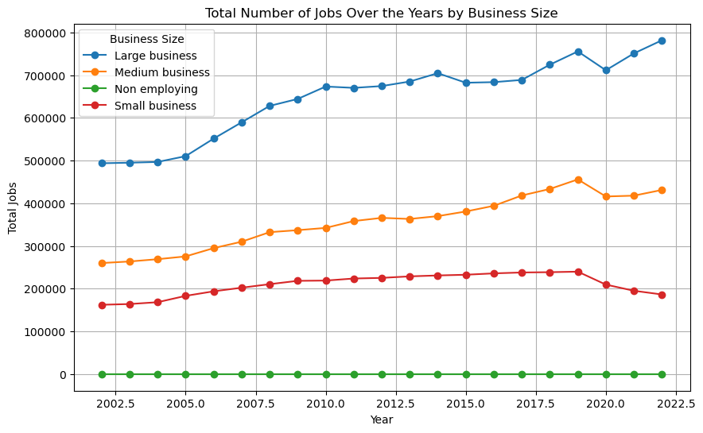

```python
# Grouping data by year and business size
grouped_data = industrysize_jobs.groupby(['census_year', 'business_size'])['total_jobs'].sum().unstack()

# Plotting
plt.figure(figsize=(10, 6))
for column in grouped_data.columns:
    plt.plot(grouped_data.index, grouped_data[column], marker='o', label=column)

plt.title('Total Number of Jobs Over the Years by Business Size')
plt.xlabel('Year')
plt.ylabel('Total Jobs')
plt.legend(title='Business Size')
plt.grid(True)
plt.show()
```

```python
# Descriptive statistic by grouping different business size
industrysize_jobs_desc = industrysize_jobs.groupby('business_size')['total_jobs'].describe()

industrysize_jobs_desc
```

| business_size | count | mean | std | min | 25% | 50% | 75% | max |
| --- | --- | --- | --- | --- | --- | --- | --- | --- |
| Large business | 1076.0 | 12633.487918 | 32292.079142 | 687.0 | 2084.5 | 3882.0 | 11539.25 | 273200.0 |
| Medium business | 3095.0 | 2418.815509 | 10420.953933 | 66.0 | 222.5 | 409.0 | 1267.00 | 153302.0 |
| Non employing | 1720.0 | 0.000000 | 0.000000 | 0.0 | 0.0 | 0.0 | 0.00 | 0.0 |
| Small business | 4474.0 | 984.121144 | 5117.223702 | 3.0 | 48.0 | 108.0 | 393.50 | 80008.0 |

```python
# Replacing missing value with min value based on business size
industrysize_jobs['total_jobs'] = industrysize_jobs.groupby('business_size')['total_jobs'].transform(lambda x: x.fillna(x.min()))
```

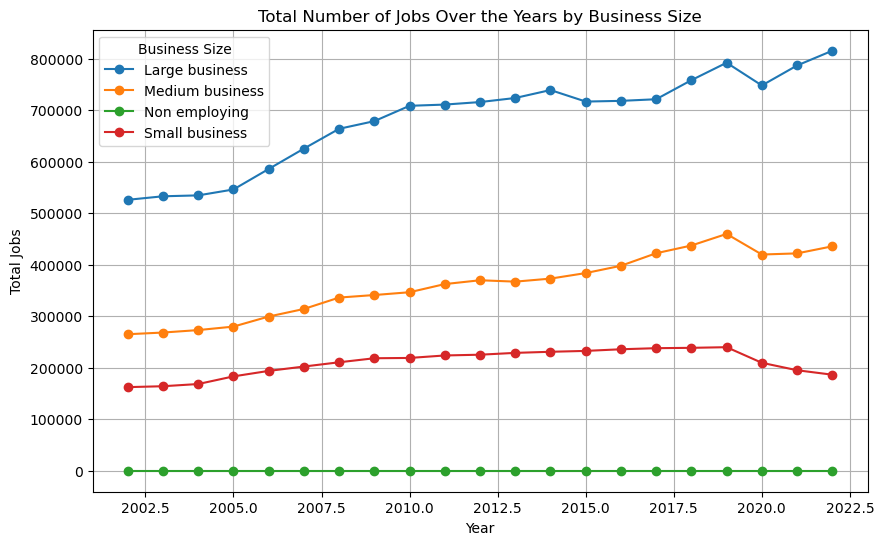

```python
# Grouping data by year and business size
grouped_data = industrysize_jobs.groupby(['census_year', 'business_size'])['total_jobs'].sum().unstack()

# Plotting
plt.figure(figsize=(10, 6))
for column in grouped_data.columns:
    plt.plot(grouped_data.index, grouped_data[column], marker='o', label=column)

plt.title('Total Number of Jobs Over the Years by Business Size')
plt.xlabel('Year')
plt.ylabel('Total Jobs')
plt.legend(title='Business Size')
plt.grid(True)
plt.show()
```

The industrysize_jobs dataset contains 4,327 missing entries in the total_jobs column, which indicates the total number of jobs or employees hired across various business sizes. To address these missing values, we have imputed them with the minimum number of employees typical for each respective business size.

Using the minimum number of employees for imputation is practical because it provides a conservative estimate that avoids overestimating the employment impact of smaller businesses.

```python
# Check for duplicates and show the number of duplicate rows
duplicate_count_before = industrysize_jobs.duplicated().sum()
print(f"Number of duplicate rows: {duplicate_count_before}")
```

```
Number of duplicate rows: 0
```

# Business establishments location and industry classification

```python
industryinfo_classification.info()
```

```
<class 'pandas.core.frame.DataFrame'>
RangeIndex: 374210 entries, 0 to 374209
Data columns (total 11 columns):
 #   Column                        Non-Null Count   Dtype
---  ------                        --------------   -----
 0   census_year                   374210 non-null  int64
 1   block_id                      374210 non-null  int64
 2   property_id                   374210 non-null  int64
 3   base_property_id              374210 non-null  int64
 4   clue_small_area               374210 non-null  object
 5   trading_name                  374083 non-null  object
 6   business_address              374209 non-null  object
 7   industry_anzsic4_code         374210 non-null  int64
 8   industry_anzsic4_description  374210 non-null  object
 9   longitude                     369425 non-null  float64
 10  latitude                      369425 non-null  float64
dtypes: float64(2), int64(5), object(4)
memory usage: 31.4+ MB
```

```python
# Detect missing values
missing_values = industryinfo_classification.isnull().sum()
print(missing_values)
```

```
census_year                        0
block_id                           0
property_id                        0
base_property_id                   0
clue_small_area                    0
trading_name                     127
business_address                   1
industry_anzsic4_code              0
industry_anzsic4_description       0
longitude                       4785
latitude                        4785
dtype: int64
```

```python
# Remove all rows which have missing values
industryinfo_classified=industryinfo_classification.dropna()
```

```python
industryinfo_classified.isnull().sum()
```

```
census_year                     0
block_id                        0
property_id                     0
base_property_id                0
clue_small_area                 0
trading_name                    0
business_address                0
industry_anzsic4_code           0
industry_anzsic4_description    0
longitude                       0
latitude                        0
dtype: int64
```

```python
# Check for duplicates and show the number of duplicate rows
duplicate_count_before = industryinfo_classified.duplicated().sum()
print(f"Number of duplicate rows: {duplicate_count_before}")
```

```
Number of duplicate rows: 0
```

We have succesfully cleaned the dataset and replaced missing values appropriately.

# Exploratory Data Analysis

We will conduct an exploratory analysis of business establishments and jobs data, focusing on how businesses are distributed across different industries and sizes, and how these factors influence total employment. By leveraging various visualizations and trend analyses, we aim to uncover key patterns and insights that will provide a deeper understanding of the economic landscape and inform strategic decision-making.

Initially, the exploratory data analysis is performed for the "Business establishments and jobs data by business size and industry" to get the hidden facts from the datatset.

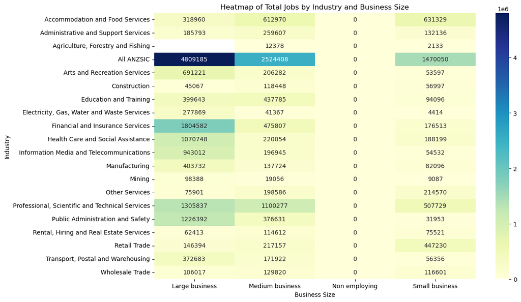

```python
# Create a pivot table
pivot_table = industrysize_jobs.pivot_table(
    values='total_jobs',
    index='anzsic_indusrty',
    columns='business_size',
    aggfunc='sum'
)

# Create a heatmap
plt.figure(figsize=(12, 8))
sns.heatmap(pivot_table, annot=True, fmt='.0f', cmap='YlGnBu')
plt.title('Heatmap of Total Jobs by Industry and Business Size')
plt.xlabel('Business Size')
plt.ylabel('Industry')
plt.show()
```

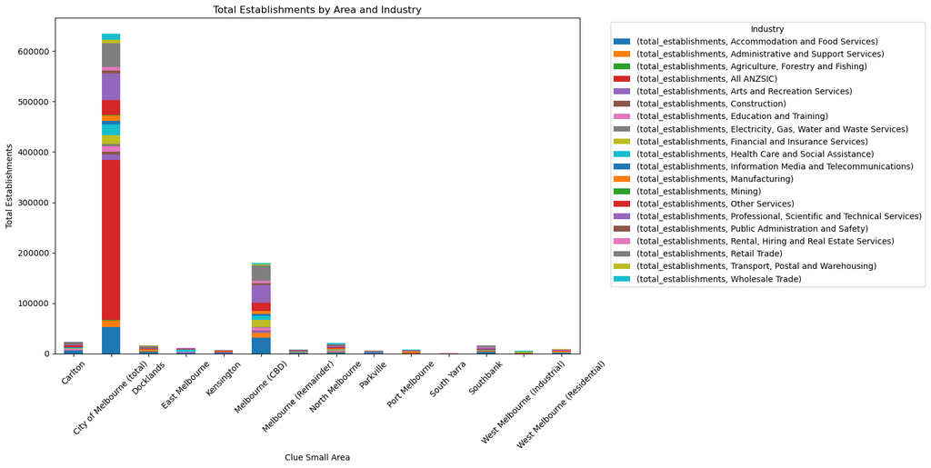

```python
# Create a stacked bar chart
plt.figure(figsize=(16, 8))
business_area_industry = industrysize_jobs.groupby(['clue_small_area', 'anzsic_indusrty']).agg({
    'total_establishments': 'sum'
}).unstack().fillna(0)

business_area_industry.plot(kind='bar', stacked=True, ax=plt.gca())
plt.title('Total Establishments by Area and Industry')
plt.xlabel('Clue Small Area')
plt.ylabel('Total Establishments')
plt.xticks(rotation=45)
plt.legend(title='Industry', bbox_to_anchor=(1.05, 1), loc='upper left')
plt.tight_layout()
plt.show()
```

The bar chart illustrates the distribution of total business establishments across various Clue Small Areas within the City of Melbourne. The "City of Melbourne (total)" area, unsurprisingly, has the highest concentration of establishments, with a significant dominance in the "All ANZSIC" category, followed by "Melbourne (CBD)" which shows a diverse representation across multiple industries. Other areas like Docklands, South Yarra, and Port Melbourne have a much smaller, yet varied, distribution of establishments across different industries. This visualization highlights the central role of Melbourne's CBD in hosting a large number of businesses, reflecting its importance as a key economic hub in the region.

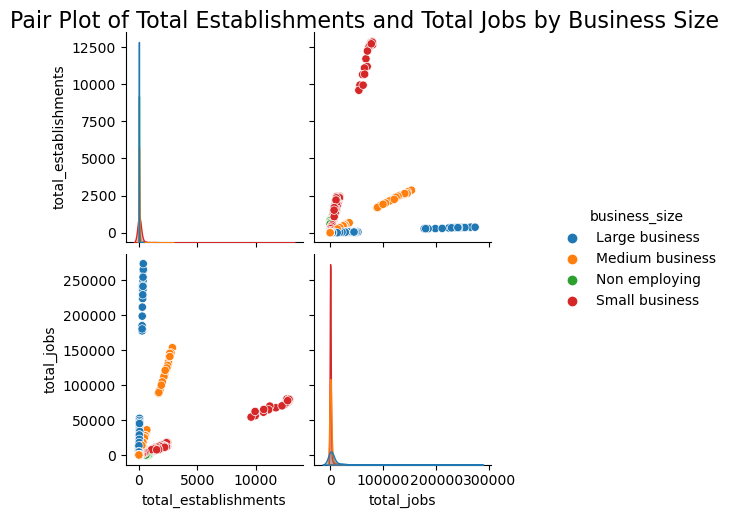

```python
# Creating a pairplot
plt.figure(figsize=(12, 8))
sns.pairplot(industrysize_jobs, hue='business_size', vars=['total_establishments', 'total_jobs'])

# Set title (note: title will not appear directly on the pairplot)
plt.suptitle('Pair Plot of Total Establishments and Total Jobs by Business Size', y=1.02, fontsize=16)

plt.show()
```

The pair plot visualizes the relationships between total establishments and total jobs across different business sizes. It shows that large businesses generally have a higher number of jobs but fewer establishments compared to small and medium-sized businesses. Small businesses, represented by red dots, are more concentrated in both the number of establishments and jobs, indicating a larger presence but fewer employees per establishment. Medium businesses occupy a middle ground, while non-employing businesses (green) are clustered close to the origin, reflecting minimal job creation despite a number of establishments. This plot helps to identify the scale and impact of different business sizes within the dataset.

```python
# Convert the 'census_year' column to datetime format, if it's not already
industrysize_jobs['census_year'] = pd.to_datetime(industrysize_jobs['census_year'], errors='coerce', format='%Y')

# Group data by year and industry, then calculate the sum of total establishments and total jobs
industry_yearly_data = industrysize_jobs.groupby([industrysize_jobs['census_year'].dt.year, 'anzsic_indusrty']).agg({
    'total_establishments': 'sum',
    'total_jobs': 'sum'
}).reset_index()

# Create a line plot for total establishments over time, by industry
fig_establishments = px.line(
    industry_yearly_data,
    x='census_year',
    y='total_establishments',
    color='anzsic_indusrty',
    title='Yearly Trends in Total Establishments by Industry',
    labels={'census_year': 'Year', 'total_establishments': 'Total Establishments'},
    markers=True
)

fig_establishments.update_layout(
    xaxis_title='Year',
    yaxis_title='Total Establishments',
    legend_title_text='Industry',
    width=900,
    height=600
)

fig_establishments.show()

# Create a line plot for total jobs over time, by industry
fig_jobs = px.line(
    industry_yearly_data,
    x='census_year',
    y='total_jobs',
    color='anzsic_indusrty',
    title='Yearly Trends in Total Jobs by Industry',
    labels={'census_year': 'Year', 'total_jobs': 'Total Jobs'},
    markers=True
)

fig_jobs.update_layout(
    xaxis_title='Year',
    yaxis_title='Total Jobs',
    legend_title_text='Industry',
    width=900,
    height=600
)

fig_jobs.show()
```

Further the analysis is performed for the "Business establishments location and industry classification" to uncover the hidden information for the dataset.

The worldcloud is displayed and most important words with the business names are shown here. It is very useful to finds them.

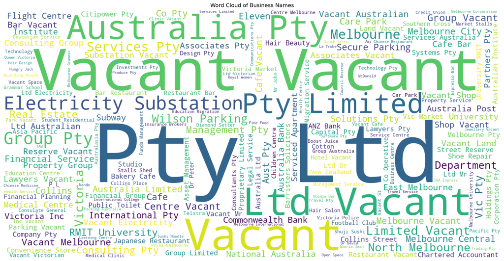

```python
# Word Cloud of Business Names
wordcloud = WordCloud(width=1600, height=800, background_color='white').generate(' '.join(industryinfo_classified['trading_name']))
plt.figure(figsize=(20,10))
plt.imshow(wordcloud, interpolation='bilinear')
plt.axis('off')
plt.title('Word Cloud of Business Names')
plt.show()
```

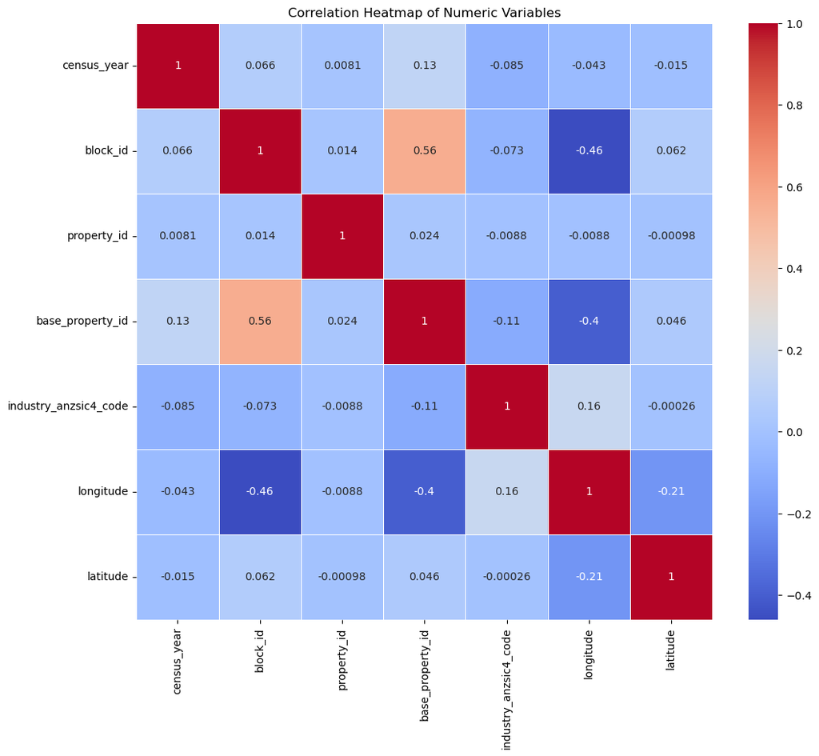

```python
# Correlation Heatmap
numeric_df = industryinfo_classified.select_dtypes(include=[np.number])
plt.figure(figsize=(12, 10))
sns.heatmap(numeric_df.corr(), annot=True, cmap='coolwarm', linewidths=0.5)
plt.title('Correlation Heatmap of Numeric Variables')
plt.show()
```

A business density heatmap by CLUE (Census Local Unit Establishments) Small Area and Census Year for various locations in the City of Melbourne is presented here. The heatmap displays the number of businesses or establishments in each CLUE Small Area over time, from 2002 to 2022.

This information can be useful for understanding the spatial distribution and trends of business activities in the Melbourne metropolitan area.

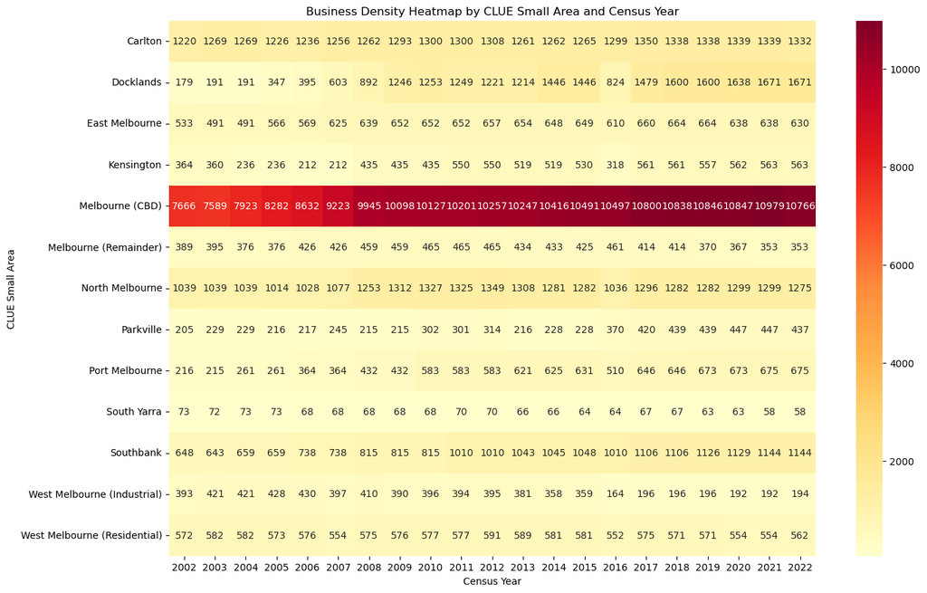

```python
# Business Density Heatmap by CLUE Small Area
pivot = industryinfo_classified.pivot_table(
    index='clue_small_area',
    columns='census_year',
    values='property_id',
    aggfunc='count'
)
plt.figure(figsize=(15, 10))
sns.heatmap(pivot, cmap='YlOrRd', annot=True, fmt='g')
plt.title('Business Density Heatmap by CLUE Small Area and Census Year')
plt.xlabel('Census Year')
plt.ylabel('CLUE Small Area')
plt.show()
```

The industry composition in the top 10 CLUE (Census Local Unit Establishments) Small Areas in Melbourne, Australia given here. The vertical axis represents the total number of businesses, and the horizontal axis lists the different CLUE Small Areas.

The key observations from the chart are:

1. The Melbourne (CBD) area has the highest total number of businesses, with a significant portion in the "Vacant Space" industry.
2. Other areas like Carlton, Docklands, and North Melbourne also have a large presence of "Vacant Space" businesses.
3. Cafes and Restaurants are a prominent industry in many of the CLUE Small Areas, particularly in areas like Melbourne (CBD), Carlton, and Southbank.
4. Legal Services and Takeaway Food Services are also noticeable industries across several CLUE Small Areas.
5. Computer System Design and Related Services is an industry with a relatively smaller presence compared to the others shown in the chart.

This information provides insights into the industry composition and business landscape within the top 10 CLUE Small Areas in Melbourne, which can be useful for understanding the economic activity and trends in the city.

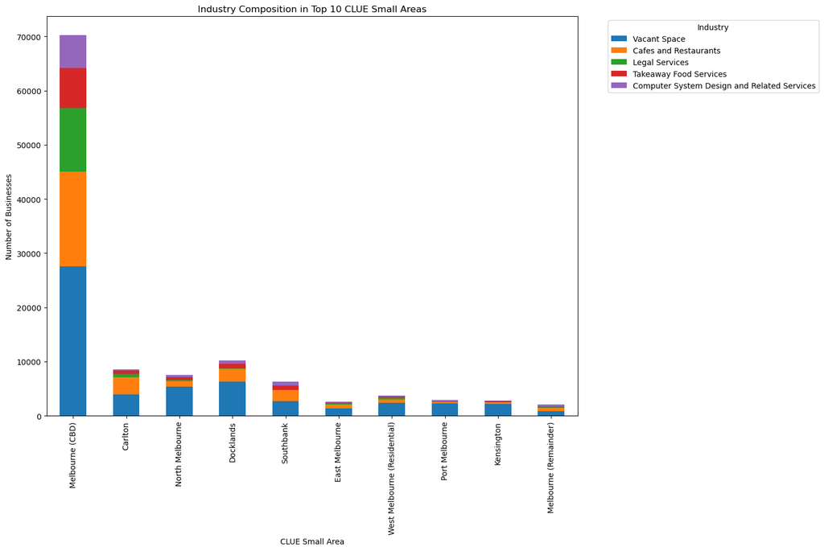

```python
# Industry Composition by CLUE Small Area
top_areas = industryinfo_classified['clue_small_area'].value_counts().nlargest(10).index
top_industries = industryinfo_classified['industry_anzsic4_description'].value_counts().nlargest(5).index

industry_area = pd.crosstab(
    industryinfo_classified['clue_small_area'],
    industryinfo_classified['industry_anzsic4_description']
)
industry_area = industry_area.loc[top_areas, top_industries]

industry_area.plot(kind='bar', stacked=True, figsize=(15, 10))
plt.title('Industry Composition in Top 10 CLUE Small Areas')
plt.xlabel('CLUE Small Area')
plt.ylabel('Number of Businesses')
plt.legend(title='Industry', bbox_to_anchor=(1.05, 1), loc='upper left')
plt.tight_layout()
plt.show()
```

```python
# Create a scatter plot with latitude, longitude, and industry
fig = px.scatter(
    industryinfo_classified,
    x='longitude',
    y='latitude',
    color='industry_anzsic4_description',  # Color by industry description
    size='block_id',  # Size by number of businesses in each block
    hover_name='trading_name',  # Show trading name on hover
    title='Geographical Distribution of Businesses by Industry',
    labels={'longitude': 'Longitude', 'latitude': 'Latitude'}
)

fig.show()
```

Some key observations:

1. The Melbourne (CBD) area has the highest overall business density, with a large presence in Vacant Space, Legal Services, and Cafes and Restaurants.
2. Docklands and North Melbourne also have significant business activity, particularly in Vacant Space and Cafes and Restaurants.
3. Suburban areas like Kensington and Parkville have a smaller overall business presence compared to the central and inner-city regions.
4. The industry composition varies across the different areas, with some areas specializing in certain industries more than others.

This treemap visualization provides a comprehensive overview of the spatial distribution and industry composition of businesses across the Melbourne metropolitan area, which can be useful for understanding the economic landscape and identifying potential opportunities or trends.

```python
import plotly.express as px

# Prepare the data for treemap
treemap_data = industryinfo_classified.groupby(['clue_small_area', 'industry_anzsic4_description']).size().reset_index(name='counts')

# Create the treemap
fig = px.treemap(treemap_data,
                 path=['clue_small_area', 'industry_anzsic4_description'],
                 values='counts',
                 title='Treemap of Businesses by Area and Industry')

fig.show()
```

The distribution of easting (a geographic coordinate) across different suburbs in the Melbourne area is listed here. Each data point represents a suburb, and the vertical axis shows the easting value for that suburb.

This visualization is useful for understanding the geographic positioning of the different suburbs in relation to the east-west axis, which may be relevant for urban planning, transportation, or other spatial analyses involving the Melbourne metropolitan area.

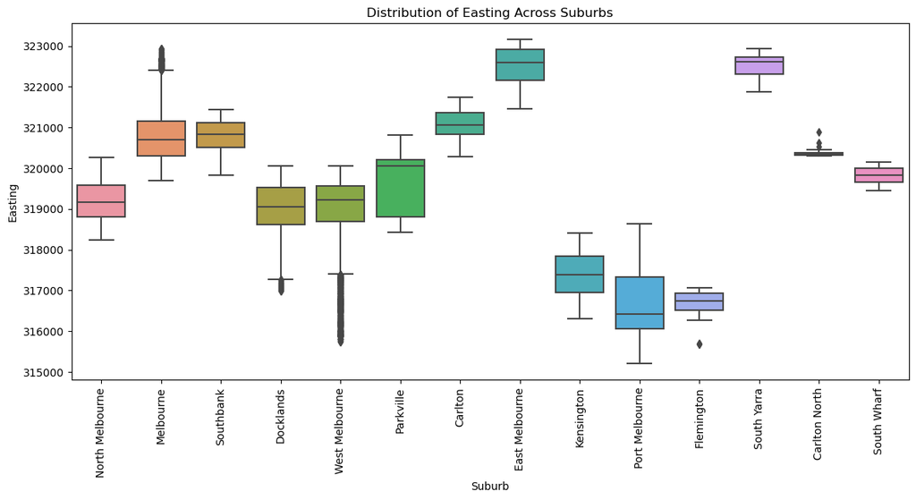

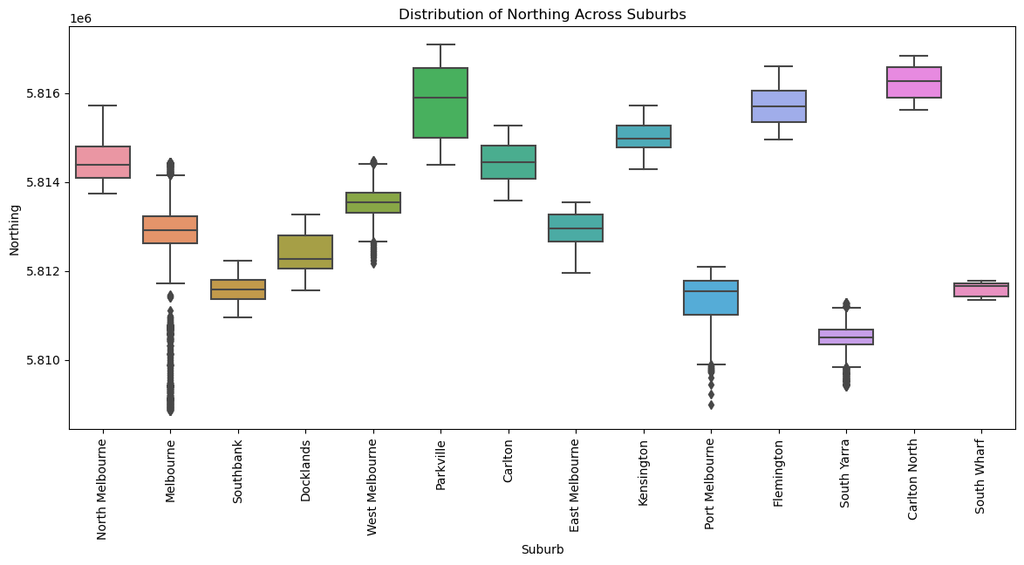

```python
# Box plot of easting across suburbs
plt.figure(figsize=(14, 6))
sns.boxplot(data=street_add_cleaned, x='suburb', y='easting')
plt.xticks(rotation=90)
plt.title('Distribution of Easting Across Suburbs')
plt.xlabel('Suburb')
plt.ylabel('Easting')
plt.show()

# Box plot of northing across suburbs
plt.figure(figsize=(14, 6))
sns.boxplot(data=street_add_cleaned, x='suburb', y='northing')
plt.xticks(rotation=90)
plt.title('Distribution of Northing Across Suburbs')
plt.xlabel('Suburb')
plt.ylabel('Northing')
plt.show()
```

# Data Modelling

Simultaneously, the regression model will focus on predicting the total number of jobs (total_jobs) as the target variable, leveraging the same set of features. This regression analysis will allow us to forecast employment trends based on business characteristics and location data. Through careful selection of features and model tuning, we aim to uncover patterns that can inform economic and urban planning decisions, with the classification model providing insights into business categorization and the regression model offering projections on job creation.

Now we want to to merge the data for modeling phase.

```python
street_add_cleaned.info()
industrysize_jobs.info()
industryinfo_classified.info()
```

```
<class 'pandas.core.frame.DataFrame'>
Int64Index: 62338 entries, 0 to 63720
Data columns (total 13 columns):
 #   Column        Non-Null Count  Dtype
---  ------        --------------  -----
 0   geo_point_2d  62338 non-null  object
 1   geo_shape     62338 non-null  object
 2   suburb_id     62338 non-null  float64
 3   latitude      62338 non-null  float64
 4   street_no     62338 non-null  object
 5   str_name      62338 non-null  object
 6   address_pnt   62338 non-null  object
 7   easting       62338 non-null  float64
 8   northing      62338 non-null  float64
 9   gisid         62338 non-null  int64
 10  longitude     62338 non-null  float64
 11  suburb        62338 non-null  object
 12  street_id     62338 non-null  int64
dtypes: float64(5), int64(2), object(6)
memory usage: 6.7+ MB
<class 'pandas.core.frame.DataFrame'>
RangeIndex: 14692 entries, 0 to 14691
Data columns (total 7 columns):
 #   Column                Non-Null Count  Dtype
---  ------                --------------  -----
 0   census_year           14692 non-null  datetime64[ns]
 1   clue_small_area       14692 non-null  object
 2   anzsic_indusrty       14692 non-null  object
 3   clue_industry         14692 non-null  object
 4   business_size         14692 non-null  object
 5   total_establishments  14692 non-null  int64
 6   total_jobs            14692 non-null  float64
dtypes: datetime64[ns](1), float64(1), int64(1), object(4)
memory usage: 803.6+ KB
<class 'pandas.core.frame.DataFrame'>
Int64Index: 369329 entries, 0 to 374209
Data columns (total 11 columns):
 #   Column                        Non-Null Count   Dtype
---  ------                        --------------   -----
 0   census_year                   369329 non-null  int64
 1   block_id                      369329 non-null  int64
 2   property_id                   369329 non-null  int64
 3   base_property_id              369329 non-null  int64
 4   clue_small_area               369329 non-null  object
 5   trading_name                  369329 non-null  object
 6   business_address              369329 non-null  object
 7   industry_anzsic4_code         369329 non-null  int64
 8   industry_anzsic4_description  369329 non-null  object
 9   longitude                     369329 non-null  float64
 10  latitude                      369329 non-null  float64
dtypes: float64(2), int64(5), object(4)
memory usage: 33.8+ MB
```

Merging the dataset

```python
# Ensure Busi_jobs_size_industry has only one row per clue_small_area
industrysize_jobs_unique = industrysize_jobs.groupby('clue_small_area').first().reset_index()


# Merge the DataFrames
merged_df5 = pd.merge(industryinfo_classified,
                     industrysize_jobs_unique[['clue_small_area', 'anzsic_indusrty', 'clue_industry', 'business_size', 'total_establishments', 'total_jobs']],
                     on='clue_small_area',
                     how='left')

# Check the result
print(f"Number of rows in merged DataFrame: {len(merged_df5)}")
print(merged_df5.info())
```

```
Number of rows in merged DataFrame: 369329
<class 'pandas.core.frame.DataFrame'>
Int64Index: 369329 entries, 0 to 369328
Data columns (total 16 columns):
 #   Column                        Non-Null Count   Dtype
---  ------                        --------------   -----
 0   census_year                   369329 non-null  int64
 1   block_id                      369329 non-null  int64
 2   property_id                   369329 non-null  int64
 3   base_property_id              369329 non-null  int64
 4   clue_small_area               369329 non-null  object
 5   trading_name                  369329 non-null  object
 6   business_address              369329 non-null  object
 7   industry_anzsic4_code         369329 non-null  int64
 8   industry_anzsic4_description  369329 non-null  object
 9   longitude                     369329 non-null  float64
 10  latitude                      369329 non-null  float64
 11  anzsic_indusrty               369329 non-null  object
 12  clue_industry                 369329 non-null  object
 13  business_size                 369329 non-null  object
 14  total_establishments          369329 non-null  int64
 15  total_jobs                    369329 non-null  float64
dtypes: float64(3), int64(6), object(7)
memory usage: 47.9+ MB
None
```

```python
# Detect missing values
missing_values = merged_df5.isnull().sum()
print(missing_values)

# Check for duplicates and show the number of duplicate rows
duplicate_count_before = merged_df5.duplicated().sum()
print(f"Number of duplicate rows: {duplicate_count_before}")
```

```
census_year                     0
block_id                        0
property_id                     0
base_property_id                0
clue_small_area                 0
trading_name                    0
business_address                0
industry_anzsic4_code           0
industry_anzsic4_description    0
longitude                       0
latitude                        0
anzsic_indusrty                 0
clue_industry                   0
business_size                   0
total_establishments            0
total_jobs                      0
dtype: int64
Number of duplicate rows: 0
```

```python
# Merge street_address and merge data on latitude and longitude
merged_df2 = pd.merge(merged_df5, street_add_cleaned,
                     on=['latitude', 'longitude'],
                     how='left')

merged_df2.info()
```

```
<class 'pandas.core.frame.DataFrame'>
Int64Index: 369329 entries, 0 to 369328
Data columns (total 27 columns):
 #   Column                        Non-Null Count   Dtype
---  ------                        --------------   -----
 0   census_year                   369329 non-null  int64
 1   block_id                      369329 non-null  int64
 2   property_id                   369329 non-null  int64
 3   base_property_id              369329 non-null  int64
 4   clue_small_area               369329 non-null  object
 5   trading_name                  369329 non-null  object
 6   business_address              369329 non-null  object
 7   industry_anzsic4_code         369329 non-null  int64
 8   industry_anzsic4_description  369329 non-null  object
 9   longitude                     369329 non-null  float64
```

[output cut: 19 more lines]

```python
# Detect missing values
missing_values = merged_df2.isnull().sum()
print(missing_values)

# Check for duplicates and show the number of duplicate rows
duplicate_count_before = merged_df2.duplicated().sum()
print(f"Number of duplicate rows: {duplicate_count_before}")

# List of columns to remove
columns_to_remove = [
    'geo_point_2d',
    'geo_shape',
    'suburb_id',
    'street_no',
    'str_name',
    'address_pnt',
    'easting',
    'northing',
    'gisid',
    'suburb',
    'street_id'
]

# Remove the specified columns
cleaned_df = merged_df2.drop(columns=columns_to_remove, errors='ignore')

print(cleaned_df.info())
```

```
census_year                          0
block_id                             0
property_id                          0
base_property_id                     0
clue_small_area                      0
trading_name                         0
business_address                     0
industry_anzsic4_code                0
industry_anzsic4_description         0
longitude                            0
latitude                             0
anzsic_indusrty                      0
clue_industry                        0
business_size                        0
total_establishments                 0
total_jobs                           0
geo_point_2d                    369329
geo_shape                       369329
suburb_id                       369329
street_no                       369329
str_name                        369329
address_pnt                     369329
easting                         369329
northing                        369329
gisid                           369329
suburb                          369329
street_id                       369329
dtype: int64
Number of duplicate rows: 0
<class 'pandas.core.frame.DataFrame'>
Int64Index: 369329 entries, 0 to 369328
Data columns (total 16 columns):
 #   Column                        Non-Null Count   Dtype
---  ------                        --------------   -----
 0   census_year                   369329 non-null  int64
 1   block_id                      369329 non-null  int64
 2   property_id                   369329 non-null  int64
 3   base_property_id              369329 non-null  int64
 4   clue_small_area               369329 non-null  object
 5   trading_name                  369329 non-null  object
 6   business_address              369329 non-null  object
 7   industry_anzsic4_code         369329 non-null  int64
 8   industry_anzsic4_description  369329 non-null  object
 9   longitude                     369329 non-null  float64
 10  latitude                      369329 non-null  float64
 11  anzsic_indusrty               369329 non-null  object
 12  clue_industry                 369329 non-null  object
 13  business_size                 369329 non-null  object
 14  total_establishments          369329 non-null  int64
 15  total_jobs                    369329 non-null  float64
dtypes: float64(3), int64(6), object(7)
memory usage: 47.9+ MB
None
```

```python
cleaned_df.head()
```

|  | census_year | block_id | property_id | base_property_id | clue_small_area | trading_name | business_address | industry_anzsic4_code | industry_anzsic4_description | longitude | latitude | anzsic_indusrty | clue_industry | business_size | total_establishments | total_jobs |
| --- | --- | --- | --- | --- | --- | --- | --- | --- | --- | --- | --- | --- | --- | --- | --- | --- |
| 0 | 2017 | 266 | 109851 | 109851 | Carlton | Metropoli's Research Pty Ltd | Level 1, 74 Victoria Street CARLTON 3053 | 6950 | Market Research and Statistical Services | 144.965352 | -37.806701 | Administrative and Support Services | Admin and Support Services | Medium business | 7 | 209.0 |
| 1 | 2017 | 266 | 109851 | 109851 | Carlton | J Hong Restaurant | Ground , 74 Victoria Street CARLTON 3053 | 4511 | Cafes and Restaurants | 144.965352 | -37.806701 | Administrative and Support Services | Admin and Support Services | Medium business | 7 | 209.0 |
| 2 | 2017 | 266 | 534003 | 534003 | Carlton | St2 Expresso | 70 Victoria Street CARLTON 3053 | 4512 | Takeaway Food Services | 144.965473 | -37.806714 | Administrative and Support Services | Admin and Support Services | Medium business | 7 | 209.0 |
| 3 | 2017 | 266 | 664003 | 664003 | Carlton | RMIT Resources Ltd | 20 Cardigan Street CARLTON 3053 | 8102 | Higher Education | 144.964753 | -37.806312 | Administrative and Support Services | Admin and Support Services | Medium business | 7 | 209.0 |
| 4 | 2017 | 266 | 664005 | 664005 | Carlton | vacant | 24 Cardigan Street CARLTON 3053 | 0 | Vacant Space | 144.964772 | -37.806203 | Administrative and Support Services | Admin and Support Services | Medium business | 7 | 209.0 |

```python
# Detect missing values
missing_values = merged_df5.isnull().sum()
print(missing_values)

# Check for duplicates and show the number of duplicate rows
duplicate_count_before = merged_df5.duplicated().sum()
print(f"Number of duplicate rows: {duplicate_count_before}")
```

```
census_year                     0
block_id                        0
property_id                     0
base_property_id                0
clue_small_area                 0
trading_name                    0
business_address                0
industry_anzsic4_code           0
industry_anzsic4_description    0
longitude                       0
latitude                        0
anzsic_indusrty                 0
clue_industry                   0
business_size                   0
total_establishments            0
total_jobs                      0
dtype: int64
Number of duplicate rows: 0
```

# Classification Model

The target for classification model is to be able to predict the business size (business_size) i.e., target class, using a robust set of features.

```python
cleaned_df.info()
```

```
<class 'pandas.core.frame.DataFrame'>
Int64Index: 369329 entries, 0 to 369328
Data columns (total 16 columns):
 #   Column                        Non-Null Count   Dtype
---  ------                        --------------   -----
 0   census_year                   369329 non-null  int64
 1   block_id                      369329 non-null  int64
 2   property_id                   369329 non-null  int64
 3   base_property_id              369329 non-null  int64
 4   clue_small_area               369329 non-null  object
 5   trading_name                  369329 non-null  object
 6   business_address              369329 non-null  object
 7   industry_anzsic4_code         369329 non-null  int64
 8   industry_anzsic4_description  369329 non-null  object
 9   longitude                     369329 non-null  float64
 10  latitude                      369329 non-null  float64
 11  anzsic_indusrty               369329 non-null  object
 12  clue_industry                 369329 non-null  object
 13  business_size                 369329 non-null  object
 14  total_establishments          369329 non-null  int64
 15  total_jobs                    369329 non-null  float64
dtypes: float64(3), int64(6), object(7)
memory usage: 47.9+ MB
```

```python
cleaned_df['business_size'].value_counts() # target class
```

```
Large business     254033
Medium business     83769
Non employing       19451
Small business      12076
Name: business_size, dtype: int64
```

Mapping categorical variables to numerical variables

```python
# Mapping business_size to numeric values
business_size_mapping = {
    'Large business': 3,
    'Medium business': 2,
    'Small business': 1,
    'Non employing': 0
}

# Apply the mapping to the 'business_size' column
cleaned_df['business_size_numeric'] = cleaned_df['business_size'].map(business_size_mapping)

# Check the conversion
print(cleaned_df[['business_size', 'business_size_numeric']].head())
```

```
     business_size  business_size_numeric
0  Medium business                      2
1  Medium business                      2
2  Medium business                      2
3  Medium business                      2
4  Medium business                      2
```

```python
# Mapping clue_small_area to numeric values
clue_small_area_mapping = {
    'Melbourne (CBD)': 0,
    'Carlton': 1,
    'North Melbourne': 2,
    'Docklands': 3,
    'Southbank': 4,
    'East Melbourne': 5,
    'West Melbourne (Residential)': 6,
    'Port Melbourne': 7,
    'Kensington': 8,
    'Melbourne (Remainder)': 9,
    'West Melbourne (Industrial)': 10,
    'Parkville': 11,
    'South Yarra': 12
}

# Apply the mapping to the 'clue_small_area' column
cleaned_df['clue_small_area_numeric'] = cleaned_df['clue_small_area'].map(clue_small_area_mapping)

# Check the conversion
print(cleaned_df[['clue_small_area', 'clue_small_area_numeric']].head())
```

```
  clue_small_area  clue_small_area_numeric
0         Carlton                        1
1         Carlton                        1
2         Carlton                        1
3         Carlton                        1
4         Carlton                        1
```

```python
# Mapping clue_industry to numeric values
clue_industry_mapping = {
    'Accommodation': 0,
    'Food and Beverage Services': 1,
    'Admin and Support Services': 2,
    'Health Care and Social Assistance': 3
}

# Apply the mapping to the 'clue_industry' column
cleaned_df['clue_industry_numeric'] = cleaned_df['clue_industry'].map(clue_industry_mapping)

# Check the conversion
print(cleaned_df[['clue_industry', 'clue_industry_numeric']].head())
```

```
                clue_industry  clue_industry_numeric
0  Admin and Support Services                      2
1  Admin and Support Services                      2
2  Admin and Support Services                      2
3  Admin and Support Services                      2
4  Admin and Support Services                      2
```

```python
cleaned_df.info()
```

```
<class 'pandas.core.frame.DataFrame'>
Int64Index: 369329 entries, 0 to 369328
Data columns (total 19 columns):
 #   Column                        Non-Null Count   Dtype
---  ------                        --------------   -----
 0   census_year                   369329 non-null  int64
 1   block_id                      369329 non-null  int64
 2   property_id                   369329 non-null  int64
 3   base_property_id              369329 non-null  int64
 4   clue_small_area               369329 non-null  object
 5   trading_name                  369329 non-null  object
 6   business_address              369329 non-null  object
 7   industry_anzsic4_code         369329 non-null  int64
 8   industry_anzsic4_description  369329 non-null  object
 9   longitude                     369329 non-null  float64
 10  latitude                      369329 non-null  float64
 11  anzsic_indusrty               369329 non-null  object
 12  clue_industry                 369329 non-null  object
 13  business_size                 369329 non-null  object
 14  total_establishments          369329 non-null  int64
 15  total_jobs                    369329 non-null  float64
 16  business_size_numeric         369329 non-null  int64
 17  clue_small_area_numeric       369329 non-null  int64
 18  clue_industry_numeric         369329 non-null  int64
dtypes: float64(3), int64(9), object(7)
memory usage: 56.4+ MB
```

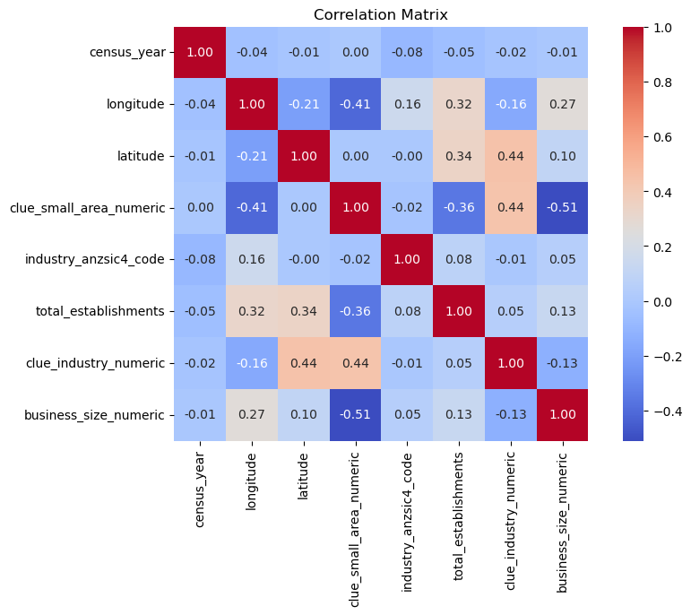

```python
# correlation plot

# Define the features and target variable
features = ['census_year', 'longitude', 'latitude', 'clue_small_area_numeric',
            'industry_anzsic4_code', 'total_establishments', 'clue_industry_numeric']
target = 'business_size_numeric'

# Create a new DataFrame with the selected features and target variable
correlation_df = cleaned_df[features + [target]]

# Calculate the correlation matrix
correlation_matrix = correlation_df.corr()

# Optionally, visualize the correlation matrix with a heatmap
import seaborn as sns
import matplotlib.pyplot as plt

plt.figure(figsize=(10, 6))
sns.heatmap(correlation_matrix, annot=True, fmt=".2f", cmap='coolwarm', square=True)
plt.title("Correlation Matrix")
plt.show()
```

```python
#  the features and target variable
features = ['longitude', 'latitude',
            'industry_anzsic4_code', 'total_establishments']
target = 'business_size_numeric'
```

```python
# Create a StandardScaler instance
scaler = StandardScaler()

# Fit the scaler to the features and transform them
normalized_features = scaler.fit_transform(cleaned_df[features])

# Create a new DataFrame with normalized features
normalized_df = pd.DataFrame(normalized_features, columns=features)

# Display the first few rows of the normalized DataFrame
print(normalized_df.head())
```

```
   longitude  latitude  industry_anzsic4_code  total_establishments
0   0.466506  0.681440               0.620677               2.05035
1   0.466506  0.681440              -0.218055               2.05035
2   0.475255  0.679954              -0.217711               2.05035
3   0.422856  0.724366               1.016831               2.05035
4   0.424256  0.736360              -1.769314               2.05035
```

```python
# Split the data into training and testing sets 70%, 30%
X_train, X_test, y_train, y_test = train_test_split(normalized_df[features], cleaned_df[target], test_size=0.3, random_state=42)
```

```
Classification Report:
                  precision    recall  f1-score   support

  Non employing     1.0000    1.0000    1.0000      5879
 Small business     1.0000    1.0000    1.0000      3627
Medium business     1.0000    1.0000    1.0000     24968
 Large business     1.0000    1.0000    1.0000     76325

       accuracy                         1.0000    110799
      macro avg     1.0000    1.0000    1.0000    110799
   weighted avg     1.0000    1.0000    1.0000    110799

Confusion Matrix:
 [[ 5879     0     0     0]
 [    0  3627     0     0]
 [    0     0 24968     0]
 [    0     0     0 76325]]
```

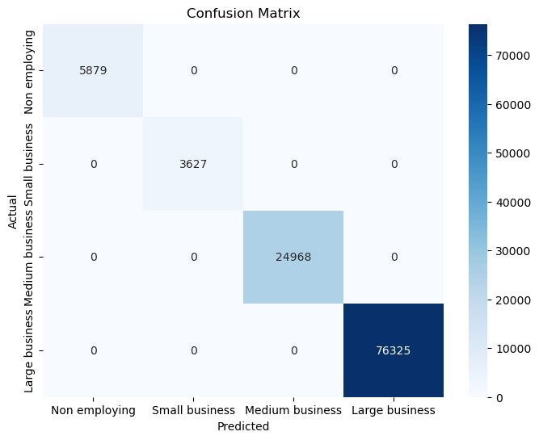

```python
# Create and train the Random Forest classifier
rf_classifier = RandomForestClassifier(random_state=42)
rf_classifier.fit(X_train, y_train)

# Make predictions on the test set
y_pred = rf_classifier.predict(X_test)

# Compute the classification report
class_summary = classification_report(y_test, y_pred, target_names=['Non employing', 'Small business', 'Medium business', 'Large business'],digits=4)

# Compute the confusion matrix
confusion_mat = confusion_matrix(y_test, y_pred)

# Display the results
print("Classification Report:\n", class_summary)
print("Confusion Matrix:\n", confusion_mat)

# Optionally, visualize the confusion matrix with a heatmap
plt.figure(figsize=(8, 6))
sns.heatmap(confusion_mat, annot=True, fmt='d', cmap='Blues', xticklabels=['Non employing', 'Small business', 'Medium business', 'Large business'], yticklabels=['Non employing', 'Small business', 'Medium business', 'Large business'])
plt.ylabel('Actual')
plt.xlabel('Predicted')
plt.title('Confusion Matrix')
plt.show()
```

```
Classification Report for Logistic Regression:
                  precision    recall  f1-score   support

  Non employing     0.8134    1.0000    0.8971      5879
 Small business     0.6284    0.9810    0.7661      3627
Medium business     0.7441    0.8345    0.7867     24968
 Large business     0.9695    0.8880    0.9270     76325

       accuracy                         0.8849    110799
      macro avg     0.7889    0.9259    0.8442    110799
   weighted avg     0.8993    0.8849    0.8885    110799

Confusion Matrix for Logistic Regression:
 [[ 5879     0     0     0]
 [    0  3558     8    61]
 [    0  2062 20837  2069]
 [ 1349    42  7157 67777]]
```

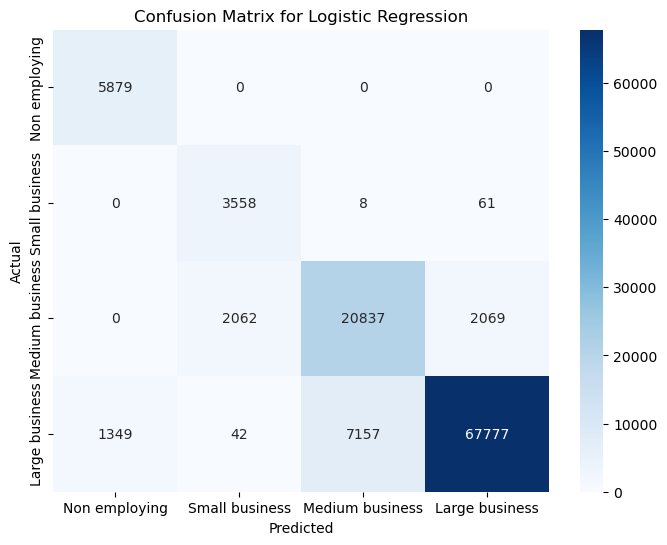

```python
# Create and train the Logistic Regression classifier
log_reg_classifier = LogisticRegression(
    C=0.5,  # Adjust regularization strength
    penalty='l2',  # Use L2 regularization
    solver='lbfgs',  # Use 'lbfgs' solver
    max_iter=1000,  # Keep the maximum iterations
    class_weight='balanced',  # Adjust weights for imbalanced classes
    tol=1e-4,  # Set a tolerance for convergence
    multi_class='multinomial'  # Use softmax for multi-class classification
)
log_reg_classifier.fit(X_train, y_train)

# Make predictions on the test set
y_pred_log_reg = log_reg_classifier.predict(X_test)

# Compute the classification report
class_summary_log_reg = classification_report(y_test, y_pred_log_reg,
                                             target_names=['Non employing', 'Small business', 'Medium business', 'Large business'],
                                             digits=4)

# Compute the confusion matrix
confusion_mat_log_reg = confusion_matrix(y_test, y_pred_log_reg)

# Display the results
print("Classification Report for Logistic Regression:\n", class_summary_log_reg)
print("Confusion Matrix for Logistic Regression:\n", confusion_mat_log_reg)

# Optionally, visualize the confusion matrix with a heatmap
plt.figure(figsize=(8, 6))
sns.heatmap(confusion_mat_log_reg, annot=True, fmt='d', cmap='Blues',
            xticklabels=['Non employing', 'Small business', 'Medium business', 'Large business'],
            yticklabels=['Non employing', 'Small business', 'Medium business', 'Large business'])
plt.ylabel('Actual')
plt.xlabel('Predicted')
plt.title('Confusion Matrix for Logistic Regression')
plt.show()
```

# Neural Network multiclassification model

```python
num_classes = len(y_train.unique())

model = Sequential([
    Dense(128,activation = 'relu', input_shape=(4,)),
    Dense(64,activation = 'relu'),
    Dense(num_classes,activation = 'softmax')
])

model.compile(optimizer='adam',
              loss = 'sparse_categorical_crossentropy',
              metrics =['accuracy'])

history = model.fit(X_train,y_train,epochs =20,batch_size=32,validation_split=0.2)

test_loss,test_acc = model.evaluate(X_test,y_test)
print("Test Accuracy ",test_acc)
```

```
Test Accuracy  0.9999819397926331
```

```python
predictions = model.predict(X_test)
predicted_classes = predictions.argmax(axis=1)
```

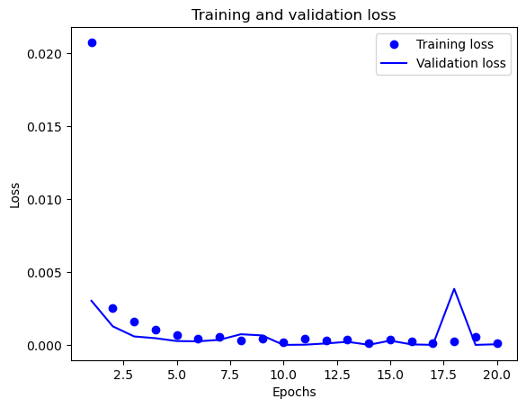

```python
history_dict = history.history
loss_values = history_dict['loss']
val_loss_values = history_dict['val_loss']

epochs = range(1, len(loss_values) + 1)

plt.plot(epochs, loss_values, 'bo', label='Training loss')
plt.plot(epochs, val_loss_values, 'b', label='Validation loss')
plt.title('Training and validation loss')
plt.xlabel('Epochs')
plt.ylabel('Loss')
plt.legend()

plt.show()
```

## Regression Modelling

In this phase of the analysis, we will apply regression techniques to model the relationships between the features and a continuous target variable. Regression analysis is valuable for understanding how the independent variables influence the dependent variable and for making predictions based on this understanding. We will utilize a suitable regression model, such as Linear Regression, to assess the influence of various features on the target variable, which could be the number of jobs or total establishments. The model will be evaluated using metrics such as R² score, Mean Absolute Error (MAE), and Mean Squared Error (MSE) to quantify its performance. Through this analysis, we aim to uncover insights into the dynamics of business establishments and employment within the dataset.

```
Mean Squared Error (MSE): 130923.17767442112
Mean Absolute Error (MAE): 262.99255646703307
R² Score: 0.6645396958258626
```

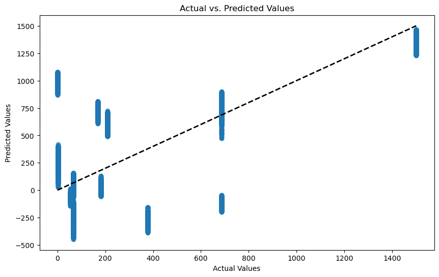

```python
# Define the target variable (e.g., total_jobs) and features
target = 'total_jobs'
features = ['census_year', 'longitude', 'latitude', 'clue_small_area_numeric',
            'industry_anzsic4_code', 'total_establishments', 'clue_industry_numeric']

# Split the data into training and testing sets
X = cleaned_df[features]
y = cleaned_df[target]
X_train, X_test, y_train, y_test = train_test_split(X, y, test_size=0.2, random_state=42)

# Create and train the Linear Regression model
linear_regressor = LinearRegression()
linear_regressor.fit(X_train, y_train)

# Make predictions on the test set
y_pred = linear_regressor.predict(X_test)

# Evaluate the model
mse = mean_squared_error(y_test, y_pred)
mae = mean_absolute_error(y_test, y_pred)
r2 = r2_score(y_test, y_pred)


# Display the evaluation metrics
print("Mean Squared Error (MSE):", mse)
print("Mean Absolute Error (MAE):", mae)
print("R² Score:", r2)

# Optionally, visualize the predictions vs. actual values
plt.figure(figsize=(10, 6))
plt.scatter(y_test, y_pred, alpha=0.7)
plt.plot([y.min(), y.max()], [y.min(), y.max()], 'k--', lw=2)
plt.xlabel('Actual Values')
plt.ylabel('Predicted Values')
plt.title('Actual vs. Predicted Values')
plt.show()
```

```
Random Forest Regressor Evaluation Metrics:
Mean Squared Error (MSE): 0.0
Mean Absolute Error (MAE): 0.0
R² Score: 1.0
```

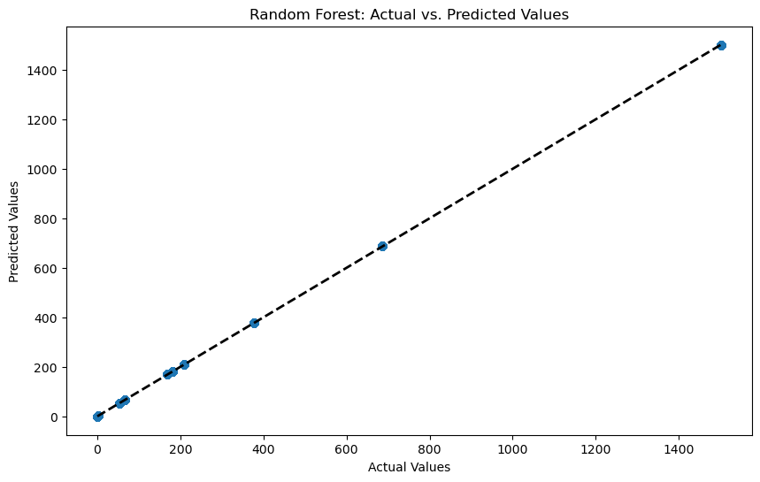

```python
# Create and train the Random Forest Regressor
rf_regressor = RandomForestRegressor(n_estimators=100, random_state=42)  # You can adjust n_estimators
rf_regressor.fit(X_train, y_train)

# Make predictions on the test set
y_pred_rf = rf_regressor.predict(X_test)

# Evaluate the model
mse_rf = mean_squared_error(y_test, y_pred_rf)
mae_rf = mean_absolute_error(y_test, y_pred_rf)
r2_rf = r2_score(y_test, y_pred_rf)

# Display the evaluation metrics
print("Random Forest Regressor Evaluation Metrics:")
print("Mean Squared Error (MSE):", mse_rf)
print("Mean Absolute Error (MAE):", mae_rf)
print("R² Score:", r2_rf)

# Optionally, visualize the predictions vs. actual values
plt.figure(figsize=(10, 6))
plt.scatter(y_test, y_pred_rf, alpha=0.7)
plt.plot([y.min(), y.max()], [y.min(), y.max()], 'k--', lw=2)
plt.xlabel('Actual Values')
plt.ylabel('Predicted Values')
plt.title('Random Forest: Actual vs. Predicted Values')
plt.show()
```